# Multivariate analysis – exercise

13 December 2024

## The Dataset

Ant community composition in 24 islands in the Thousands Island Lake, China.

https://emilio-berti.github.io/datasets/ants.zip

## The Dataset: islands

```r
islands <- read.csv("islands.csv")
head(islands, 3)
```

```
  island longitude latitude
1     S1  118.8865 29.52810
2     S2  118.8525 29.49686
3     S3  118.9067 29.50562
```

## The Dataset: ant traits

```r
traits <- read.csv("ant_traits.csv")
head(traits, 3)
```

```
  torax_length eye_width leg_length scape_length mandible_length
1    0.8844444  0.000000   1.458398    0.4617310       0.3879327
2    1.1768278  0.000000   1.552939    0.5216261       0.3639346
3    2.0600444  0.114711   1.361409    0.6837751       0.5864359
```

## The Dataset: ant composition

```r
composition <- read.csv("ant_composition.csv")
composition[1:3, 1:4]
```

```
  island Aenictus_fuchuanensis Aenictus_laeviceps Anochetus_risii
1     S1                     1                  1               1
2    S10                     1                  1               1
3    S11                     0                  1               1
```

- `island` is the ID of the island (as in `islands.csv`)
- Other columns show the presence (`1`) or absence (`0`) of each species (one column = one species) in the islands.

## Question #1

**Can you identify the general differences between ant species in morhpological traits?**

**Hint**: Use a PCA approach (`prcomp()`) and the `traits` table (*ant_traits.csv*).

## Question #2

**Can you arrange the islands in a plot ordering them by similarity in species composition?**

**Hint**: Use a nMDS approach (`MASS::isoMDS()`) and the `composition` table (*ant_composition.csv*).

**Tip**: Because you have presence/absence data, distance between communities should be calculated using an appropriate method, such a the Jaccard dissimilarity. In R, this can be done specifying `method = "binary"` in `dist()`, e.g., `dist(<table>, method = "binary")`.

## Question #3

**Can you identify a spatial gradient in the dissimilarities of ant composition between islands?**

**Hint**: Plot the nMDS axes against `longitude` and `latitude` from the `islands` table (*islands.csv*).

## Question #1

**Can you identify the general differences between ant species in morhpological traits?**

## Question #1

**Can you identify the general differences between ant species in morhpological traits?**

**Hint**: Use a PCA approach (`prcomp()`) and the `traits` table (*ant_traits.csv*).

## Answer #1

```r
pca_traits <- prcomp(traits, scale = TRUE, center = TRUE)
summary(pca_traits)
```

```
Importance of components:
                          PC1    PC2    PC3     PC4     PC5
Standard deviation     1.5656 1.0923 0.8970 0.66494 0.33020
Proportion of Variance 0.4903 0.2386 0.1609 0.08843 0.02181
Cumulative Proportion  0.4903 0.7289 0.8898 0.97819 1.00000
```

## Answer #1

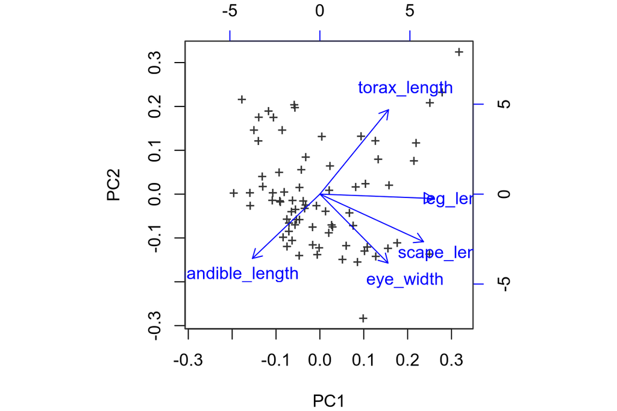

```r
biplot(pca_traits, xlabs = rep("+", nrow(traits)), col = c("grey20", "blue"))
```

## Answer #1

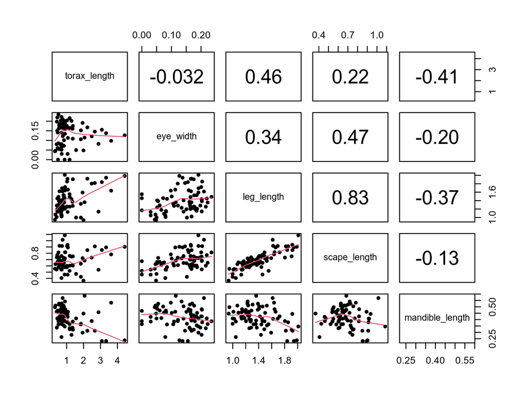

```r
pairs(traits, pch = 20, cex = 1, lower.panel = panel.smooth, upper.panel = panel.cor)
```

## Answer #1

**Gradient from ants with short body but long mandibles to ants with long body but short mandibles to ants.**

## Question #2

**Can you arrange the islands in a plot ordering them by similarity in species composition?**

## Answer #2

```r
jaccard <- dist(composition[, -1], method = "binary")
nMDS <- MASS::isoMDS(jaccard, k = 2)
```

## Answer #1

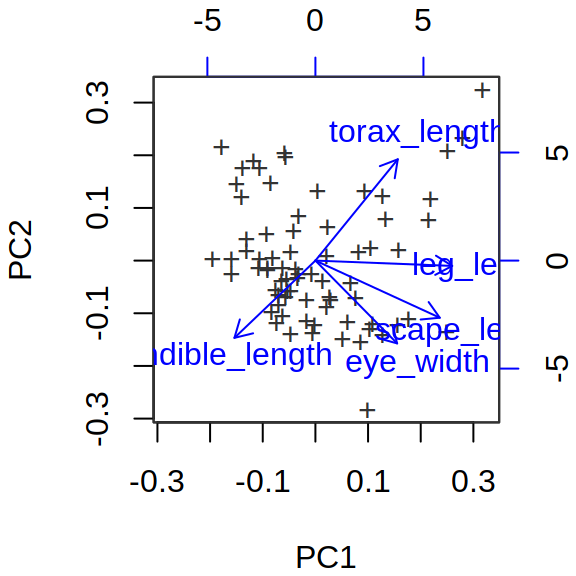

```r
biplot(pca_traits, xlabs = rep("+", nrow(traits)), col = c("grey20", "blue"))
```

1. Lengths all correlated (slightly or strongly)
2. Exception is `mandible_length` which is negatively correlated with most lengths.
3. In general, the longer the legs (`leg_Length`) and the torax (`torax_length`), the smaller the mandibles (`mandible_length`).

## Answer #1

If you plot all variables one against the other, you will also see these patterns…

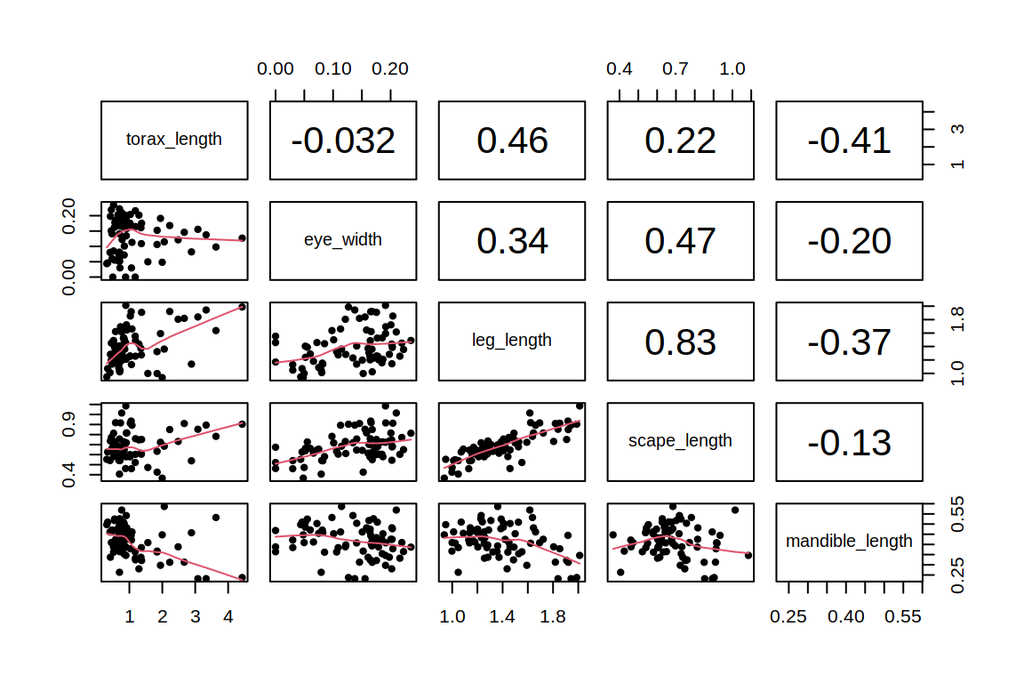

… but you need to look at 10 figures instead of one.

## Answer #1

**Gradient from ants with short body but long mandibles to ants with long body but short mandibles to ants.**

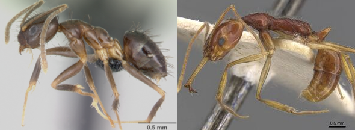

Two species as example.

## Question #2

**Can you arrange the islands in a plot ordering them by similarity in species composition?**

## Answer #2

First, we need to calculate the dissimilarity between islands. We do this using `dist()` amd specifying `method = "binary"`, as the data has `0` and `1` values.

```r
jaccard <- dist(composition[, -1], method = "binary")
```

Binary distance is also known as Jaccard dissimiliarity.

## Answer #2

We then can run a nMDS using `MASS::isoMDS()`.

```r
nMDS <- MASS::isoMDS(jaccard)
```

```
initial  value 27.717339
iter   5 value 24.592216
final  value 24.496130
converged
```

## Answer #2

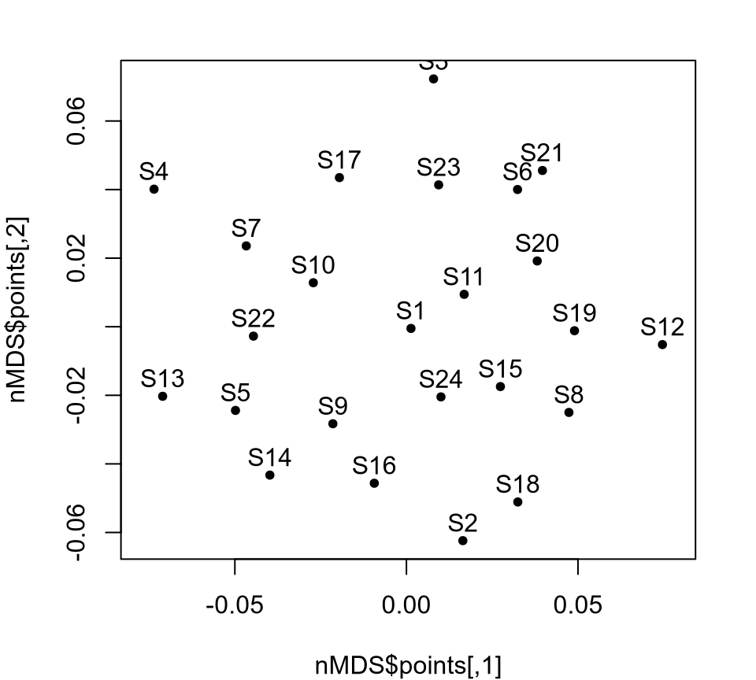

```r
plot(nMDS$points, pch = 20, asp = 1)
text(nMDS$points, labels = composition[, 1], adj = c(0.5, -0.5))
```